# notebook_phase2

```python
import pandas as pd
pd.set_option("display.max_columns", None)
import seaborn as sns
import matplotlib.pyplot as plt
```

```python
df = pd.read_csv("dataset/phase1_df.csv")
df.head()
```

|  | Age | Gender | City | Education_Level | Joining Designation | joining date | joining month | joining year | ReportCount | Active | TBV_avg | QR_avg | Income_avg | Grade_avg | income_diff_pattern | tbv_diff_pattern | qr_diff_pattern | grade_diff_pattern |
| --- | --- | --- | --- | --- | --- | --- | --- | --- | --- | --- | --- | --- | --- | --- | --- | --- | --- | --- |
| 0 | 28.000000 | 0.0 | C23 | 2 | 1 | 24 | 12 | 18 | 3 | 0 | 571860.000000 | 2.000000 | 57387.0 | 1.0 | 0.0 | -2381060.0 | 0.0 | 0.0 |
| 1 | 29.000000 | 0.0 | C9 | 0 | 1 | 1 | 9 | 19 | 3 | 0 | 40120.000000 | 1.000000 | 46368.0 | 1.0 | 0.0 | 0.0 | 0.0 | 0.0 |
| 2 | 29.608696 | 0.0 | C19 | 2 | 1 | 28 | 5 | 15 | 23 | 0 | 444045.217391 | 1.260870 | 119227.0 | 4.0 | 0.0 | -250000.0 | 0.0 | 0.0 |
| 3 | 30.000000 | 1.0 | C23 | 0 | 2 | 30 | 11 | 18 | 2 | 0 | 173400.000000 | 1.000000 | 52963.0 | 2.0 | 0.0 | -346800.0 | 0.0 | 0.0 |
| 4 | 42.142857 | 0.0 | C20 | 2 | 1 | 3 | 6 | 18 | 7 | 0 | 145377.142857 | 1.428571 | 51099.0 | 1.0 | 0.0 | -100000.0 | -1.0 | 0.0 |

```python
df.describe(include="object")
```

|  | City |
| --- | --- |
| count | 2381 |
| unique | 29 |
| top | C20 |
| freq | 152 |

```python
df.describe()
```

|  | Age | Gender | Education_Level | Joining Designation | joining date | joining month | joining year | ReportCount | Active | TBV_avg | QR_avg | Income_avg | Grade_avg | income_diff_pattern | tbv_diff_pattern | qr_diff_pattern | grade_diff_pattern |
| --- | --- | --- | --- | --- | --- | --- | --- | --- | --- | --- | --- | --- | --- | --- | --- | --- | --- |
| count | 2381.000000 | 2381.000000 | 2381.00000 | 2381.000000 | 2381.000000 | 2381.000000 | 2381.000000 | 2381.00000 | 2381.000000 | 2.381000e+03 | 2381.000000 | 2381.000000 | 2381.000000 | 2381.000000 | 2.381000e+03 | 2381.000000 | 2381.000000 |
| mean | 33.369192 | 0.410332 | 1.00756 | 1.820244 | 16.186896 | 6.958001 | 18.536329 | 8.02352 | 0.321294 | 3.120854e+05 | 1.566304 | 59232.460484 | 2.081713 | 125.096178 | -2.440566e+04 | -0.058379 | 0.018060 |
| std | 5.890732 | 0.491997 | 0.81629 | 0.841433 | 8.959616 | 3.221762 | 1.609597 | 6.78359 | 0.467071 | 4.495705e+05 | 0.719652 | 28298.214012 | 0.932257 | 968.511766 | 1.182482e+06 | 0.933703 | 0.133195 |
| min | 21.000000 | 0.000000 | 0.00000 | 1.000000 | 1.000000 | 1.000000 | 13.000000 | 1.00000 | 0.000000 | -1.979329e+05 | 1.000000 | 10747.000000 | 1.000000 | 0.000000 | -9.658160e+06 | -3.000000 | 0.000000 |
| 25% | 29.000000 | 0.000000 | 0.00000 | 1.000000 | 9.000000 | 5.000000 | 18.000000 | 3.00000 | 0.000000 | 0.000000e+00 | 1.000000 | 39104.000000 | 1.000000 | 0.000000 | -1.166600e+05 | 0.000000 | 0.000000 |
| 50% | 33.000000 | 0.000000 | 1.00000 | 2.000000 | 15.000000 | 7.000000 | 19.000000 | 5.00000 | 0.000000 | 1.506244e+05 | 1.000000 | 55285.000000 | 2.000000 | 0.000000 | 0.000000e+00 | 0.000000 | 0.000000 |
| 75% | 37.000000 | 1.000000 | 2.00000 | 2.000000 | 24.000000 | 10.000000 | 20.000000 | 10.00000 | 1.000000 | 4.294988e+05 | 2.000000 | 75835.000000 | 3.000000 | 0.000000 | 0.000000e+00 | 0.000000 | 0.000000 |
| max | 58.000000 | 1.000000 | 2.00000 | 5.000000 | 31.000000 | 12.000000 | 20.000000 | 24.00000 | 1.000000 | 3.972128e+06 | 4.000000 | 188418.000000 | 5.000000 | 12155.000000 | 2.391754e+07 | 3.000000 | 1.000000 |

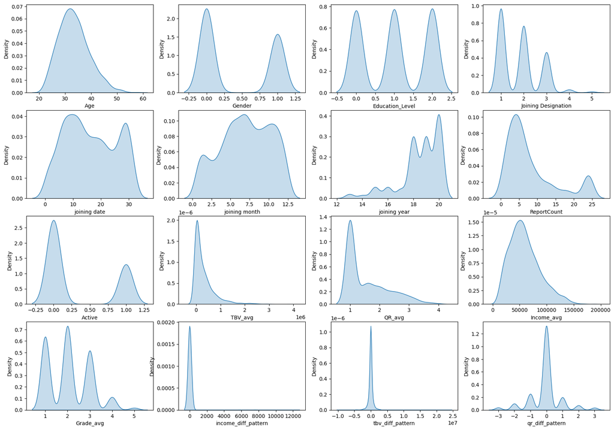

```python
fig=plt.figure(figsize=(20,14)) # width*height
for ind_number, col_name in enumerate(df.describe().columns):
    if ind_number<16:
        plt.subplot(4,4,ind_number+1)
        sns.kdeplot(df[col_name], fill=True)
```

```python
df[df["income_diff_pattern"]>10000]
```

|  | Age | Gender | City | Education_Level | Joining Designation | joining date | joining month | joining year | ReportCount | Active | TBV_avg | QR_avg | Income_avg | Grade_avg | income_diff_pattern | tbv_diff_pattern | qr_diff_pattern | grade_diff_pattern |
| --- | --- | --- | --- | --- | --- | --- | --- | --- | --- | --- | --- | --- | --- | --- | --- | --- | --- | --- |
| 10 | 41.833333 | 0.0 | C14 | 2 | 1 | 5 | 7 | 18 | 24 | 1 | 2.911162e+06 | 3.083333 | 126132.333333 | 3.416667 | 11048.0 | 1210110.0 | -2.0 | 1.0 |
| 240 | 36.666667 | 0.0 | C16 | 2 | 2 | 13 | 7 | 13 | 24 | 1 | 2.283013e+06 | 3.125000 | 139347.500000 | 4.125000 | 11492.0 | 1313620.0 | -2.0 | 1.0 |
| 456 | 52.583333 | 0.0 | C15 | 2 | 1 | 6 | 8 | 18 | 24 | 1 | 2.124457e+06 | 3.375000 | 136744.750000 | 3.250000 | 12155.0 | -2900660.0 | -2.0 | 1.0 |
| 938 | 48.333333 | 1.0 | C9 | 2 | 1 | 6 | 3 | 18 | 24 | 1 | 1.803128e+06 | 3.250000 | 126779.250000 | 3.250000 | 11269.0 | 1376900.0 | -2.0 | 1.0 |

Understanding:

- Mean income lies around 50k for all the drives.
- We have drivers with either reporting count as 5 and it keeps on droping till a certain band and then increase after 20.
- Getting a increase in number of drivers joining on yearly basis.
- June seems to be the favaouable month to join OLA for Drivers.

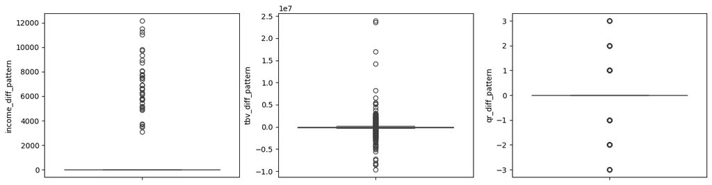

```python
fig=plt.figure(figsize=(16,4)) # width*height

plt.subplot(1,3,1)
sns.boxplot(data=df["income_diff_pattern"])

plt.subplot(1,3,2)
sns.boxplot(data=df["tbv_diff_pattern"])

plt.subplot(1,3,3)
sns.boxplot(data=df["qr_diff_pattern"])
```

- Let us categorises the values based on their magnitute.

```python
# income_diff_pattern : based on box plot let us categorize in 5 bins 1,2,3,4,5

# Define bin edges
bin_edges = [0, 2000, 4000, 8000, 10000, df['income_diff_pattern'].max()]

# Define bin labels
bin_labels = [1, 2, 3, 4, 5]

# Create a new column 'income_diff_pattern' based on the bins
df['income_diff_pattern'] = pd.cut(df['income_diff_pattern'], bins=bin_edges, labels=bin_labels, include_lowest=True).astype(int)
```

```python
# tbv_diff_pattern : based on box plot

Q1 = df["tbv_diff_pattern"].quantile(0.05)
Q2 = df["tbv_diff_pattern"].quantile(0.15)
Q3 = df["tbv_diff_pattern"].quantile(0.85)
Q4 = df["tbv_diff_pattern"].quantile(0.95)

print(Q1,Q2,Q3,Q4, df['tbv_diff_pattern'].max())


# Define bin edges
bin_edges = [df['tbv_diff_pattern'].min(), Q1, Q2, 0, Q3, Q4, df['tbv_diff_pattern'].max()]

# Define bin labels
bin_labels = [-3, -2, -1, 1, 2, 3]

# Create a new column 'income_diff_pattern' based on the bins
df['tbv_diff_pattern'] = pd.cut(df['tbv_diff_pattern'], bins=bin_edges, labels=bin_labels, include_lowest=True).astype(int)
```

```
-1048330.0 -398770.0 261100.0 950000.0 23917540.0
```

```python
df.head()
```

|  | Age | Gender | City | Education_Level | Joining Designation | joining date | joining month | joining year | ReportCount | Active | TBV_avg | QR_avg | Income_avg | Grade_avg | income_diff_pattern | tbv_diff_pattern | qr_diff_pattern | grade_diff_pattern |
| --- | --- | --- | --- | --- | --- | --- | --- | --- | --- | --- | --- | --- | --- | --- | --- | --- | --- | --- |
| 0 | 28.000000 | 0.0 | C23 | 2 | 1 | 24 | 12 | 18 | 3 | 0 | 571860.000000 | 2.000000 | 57387.0 | 1.0 | 1 | -3 | 0.0 | 0.0 |
| 1 | 29.000000 | 0.0 | C9 | 0 | 1 | 1 | 9 | 19 | 3 | 0 | 40120.000000 | 1.000000 | 46368.0 | 1.0 | 1 | -1 | 0.0 | 0.0 |
| 2 | 29.608696 | 0.0 | C19 | 2 | 1 | 28 | 5 | 15 | 23 | 0 | 444045.217391 | 1.260870 | 119227.0 | 4.0 | 1 | -1 | 0.0 | 0.0 |
| 3 | 30.000000 | 1.0 | C23 | 0 | 2 | 30 | 11 | 18 | 2 | 0 | 173400.000000 | 1.000000 | 52963.0 | 2.0 | 1 | -1 | 0.0 | 0.0 |
| 4 | 42.142857 | 0.0 | C20 | 2 | 1 | 3 | 6 | 18 | 7 | 0 | 145377.142857 | 1.428571 | 51099.0 | 1.0 | 1 | -1 | -1.0 | 0.0 |

```python
df.info()
```

```
<class 'pandas.core.frame.DataFrame'>
RangeIndex: 2381 entries, 0 to 2380
Data columns (total 18 columns):
 #   Column               Non-Null Count  Dtype
---  ------               --------------  -----
 0   Age                  2381 non-null   float64
 1   Gender               2381 non-null   float64
 2   City                 2381 non-null   object
 3   Education_Level      2381 non-null   int64
 4   Joining Designation  2381 non-null   int64
 5   joining date         2381 non-null   int64
 6   joining month        2381 non-null   int64
 7   joining year         2381 non-null   int64
 8   ReportCount          2381 non-null   int64
 9   Active               2381 non-null   int64
 10  TBV_avg              2381 non-null   float64
 11  QR_avg               2381 non-null   float64
 12  Income_avg           2381 non-null   float64
 13  Grade_avg            2381 non-null   float64
 14  income_diff_pattern  2381 non-null   int64
 15  tbv_diff_pattern     2381 non-null   int64
 16  qr_diff_pattern      2381 non-null   float64
 17  grade_diff_pattern   2381 non-null   float64
dtypes: float64(8), int64(9), object(1)
memory usage: 335.0+ KB
```

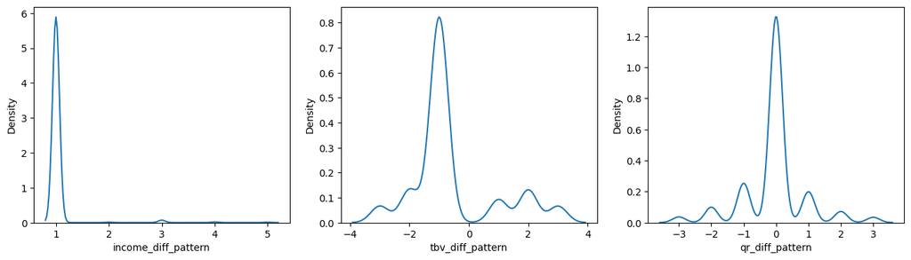

```python
fig=plt.figure(figsize=(16,4)) # width*height

plt.subplot(1,3,1)
sns.kdeplot(data=df["income_diff_pattern"])

plt.subplot(1,3,2)
sns.kdeplot(data=df["tbv_diff_pattern"])

plt.subplot(1,3,3)
sns.kdeplot(data=df["qr_diff_pattern"])
```

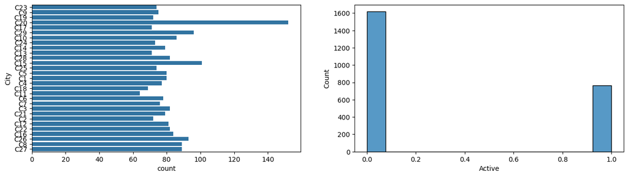

```python
fig=plt.figure(figsize=(16,4)) # width*height

plt.subplot(1,2,1)
sns.countplot(df["City"], fill=True)

plt.subplot(1,2,2)
sns.histplot(df["Active"], fill=True)
```

Understanding:

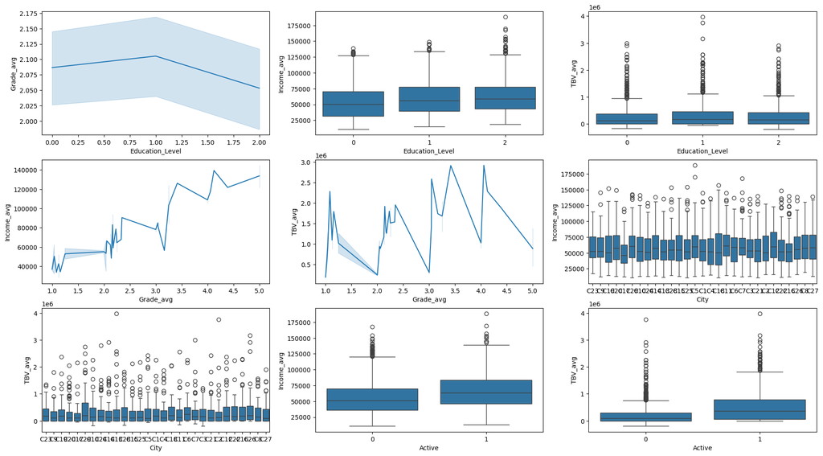

```python
fig=plt.figure(figsize=(22,12))

plt.subplot(3,3,1)
sns.lineplot(y='Grade_avg', x='Education_Level', data=df)
plt.subplot(3,3,2)
sns.boxplot(y='Income_avg', x='Education_Level', data=df)
plt.subplot(3,3,3)
sns.boxplot(y='TBV_avg', x='Education_Level', data=df)

plt.subplot(3,3,4)
sns.lineplot(y='Income_avg', x='Grade_avg', data=df)
plt.subplot(3,3,5)
sns.lineplot(y='TBV_avg', x='Grade_avg', data=df)

plt.subplot(3,3,6)
sns.boxplot(y='Income_avg', x='City', data=df)

plt.subplot(3,3,7)
sns.boxplot(y='TBV_avg', x='City', data=df)

plt.subplot(3,3,8)
sns.boxplot(y='Income_avg', x='Active', data=df)

plt.subplot(3,3,9)
sns.boxplot(y='TBV_avg', x='Active', data=df)

plt.show()
```

- Correlation between driver ratings and factors like age, income, and education.

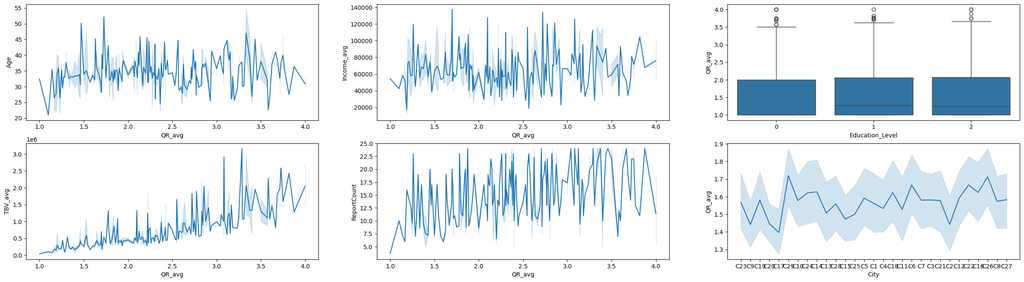

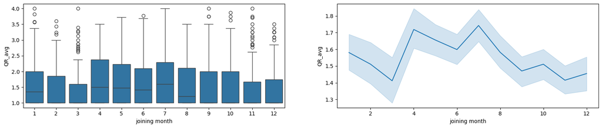

```python
fig=plt.figure(figsize=(30,12))

plt.subplot(3,3,1)
sns.lineplot(y='Age', x='QR_avg', data=df)

plt.subplot(3,3,2)
sns.lineplot(y='Income_avg', x='QR_avg', data=df)

plt.subplot(3,3,3)
sns.boxplot(y='QR_avg', x='Education_Level', data=df)

plt.subplot(3,3,4)
sns.lineplot(y='TBV_avg', x='QR_avg', data=df)

plt.subplot(3,3,5)
sns.lineplot(y='ReportCount', x='QR_avg', data=df)

plt.subplot(3,3,6)
sns.lineplot(y='QR_avg', x='City', data=df)

fig=plt.figure(figsize=(30,12))

plt.subplot(3,3,7)
sns.boxplot(y='QR_avg', x='joining month', data=df)

plt.subplot(3,3,8)
sns.lineplot(y='QR_avg', x='joining month', data=df)
```

```python
df.groupby("QR_avg")["TBV_avg"].mean()
```

```
QR_avg
1.000000    3.802113e+04
1.100000    1.000130e+05
1.142857    7.172000e+04
1.166667    1.754842e+05
1.187500    1.477394e+05
                ...
3.750000    1.588392e+06
3.769231    1.798186e+06
3.818182    2.426973e+06
3.875000    1.277854e+06
4.000000    2.051391e+06
Name: TBV_avg, Length: 163, dtype: float64
```

```python
print("Grade <-> Income")
# Calculate Pearson correlation
pearson_corr = df['Grade_avg'].corr(df['Income_avg'])
print(f"Pearson Correlation: {pearson_corr}")
# Calculate Spearman correlation
spearman_corr = df['Grade_avg'].corr(df['Income_avg'], method='spearman')
print(f"Spearman Correlation: {spearman_corr}")

print("\nGrade <-> Total Business Value")
# Calculate Pearson correlation
pearson_corr = df['Grade_avg'].corr(df['TBV_avg'])
print(f"Pearson Correlation: {pearson_corr}")
# Calculate Spearman correlation
spearman_corr = df['Grade_avg'].corr(df['TBV_avg'], method='spearman')
print(f"Spearman Correlation: {spearman_corr}")
```

```
Grade <-> Income
Pearson Correlation: 0.7396736903173439
Spearman Correlation: 0.7102193516509495

Grade <-> Total Business Value
Pearson Correlation: 0.33291162712609945
Spearman Correlation: 0.19359942881616332
```

Understandings:

- Whenever Driver's Grade changes, total Business Values has imapct. Which shows Grading has positive correlation with Business values the Driver is providing.
- With change in Grade, you income increases.

```python
print("\Age <-> Quarterly Rating")
# Calculate Pearson correlation
pearson_corr = df['Age'].corr(df['QR_avg'])
print(f"Pearson Correlation: {pearson_corr}")
# Calculate Spearman correlation
spearman_corr = df['Age'].corr(df['QR_avg'], method='spearman')
print(f"Spearman Correlation: {spearman_corr}")
```

```
\Age <-> Quarterly Rating
Pearson Correlation: 0.19510169050688675
Spearman Correlation: 0.17632230499418575
```

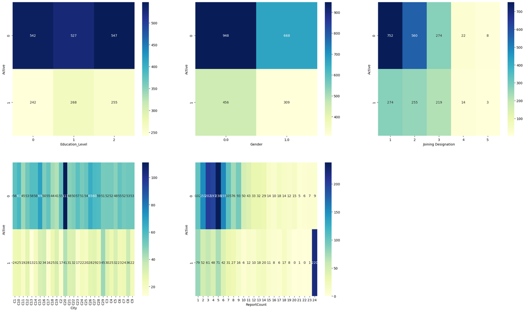

```python
# 3. CATEGORICAL VS CATEGORICAL
categorical_col = ["Education_Level", "Gender", "Joining Designation", "City","ReportCount"]
fig=plt.figure(figsize=(28,16))
for ind_val, columns in enumerate(categorical_col):
 if ind_val<6:
    plt.subplot(2,3,ind_val+1)
    cross_tab = pd.crosstab(df["Active"], df[columns])
    sns.heatmap(cross_tab,annot=True, cmap="YlGnBu", fmt='d', cbar=True)
    # Set labels and title
    plt.xlabel(columns)
    plt.ylabel('Active')
    # Show the plot
    # plt.show()
```

Trade-Off Analysis:

- From the heatmaps plotted above, it doesn't seem to have any correlation between the Education and Driver's Attrition.
- From the heatmaps it clearly indicated that if we able to hold our Driver for long, the Churn is very less.

Recommendations based on understanding

Categorical Understandings:

- Their seems to be big Churn in City C20 as compare to other cities present, we should work and understand the reason and keep the business inpact from upcoming challenges.
- Designation 1 and 5 have high changes of Leaving as compare to other Designations.
- Gender and Education seems unbiased.

Visualization understanding

- No impact of cities on Driver's Income and Business Value.
- Active Drivers seems to have better Income and contributing more as compare to Non-Active Drivers.
- With increase in Grade there is increase in Income.
- No relationship between Driver's Education and Income/Business Value.

Outliers and Influence :

- It seems that there are outliers in Drivers Income and Business Values, but after understanding business perspective we should not remove them.
- They can act as valuable information when building the prediction models.

Skeness and Correlation

```python
df.shape
```

```
(2381, 18)
```

```python
df.describe()
```

|  | Age | Gender | Education_Level | Joining Designation | joining date | joining month | joining year | ReportCount | Active | TBV_avg | QR_avg | Income_avg | Grade_avg | income_diff_pattern | tbv_diff_pattern | qr_diff_pattern | grade_diff_pattern |
| --- | --- | --- | --- | --- | --- | --- | --- | --- | --- | --- | --- | --- | --- | --- | --- | --- | --- |
| count | 2381.000000 | 2381.000000 | 2381.00000 | 2381.000000 | 2381.000000 | 2381.000000 | 2381.000000 | 2381.00000 | 2381.000000 | 2.381000e+03 | 2381.000000 | 2381.000000 | 2381.000000 | 2381.000000 | 2381.000000 | 2381.000000 | 2381.000000 |
| mean | 33.369192 | 0.410332 | 1.00756 | 1.820244 | 16.186896 | 6.958001 | 18.536329 | 8.02352 | 0.321294 | 3.120854e+05 | 1.566304 | 59232.460484 | 2.081713 | 1.040319 | -0.559849 | -0.058379 | 0.018060 |
| std | 5.890732 | 0.491997 | 0.81629 | 0.841433 | 8.959616 | 3.221762 | 1.609597 | 6.78359 | 0.467071 | 4.495705e+05 | 0.719652 | 28298.214012 | 0.932257 | 0.314983 | 1.445759 | 0.933703 | 0.133195 |
| min | 21.000000 | 0.000000 | 0.00000 | 1.000000 | 1.000000 | 1.000000 | 13.000000 | 1.00000 | 0.000000 | -1.979329e+05 | 1.000000 | 10747.000000 | 1.000000 | 1.000000 | -3.000000 | -3.000000 | 0.000000 |
| 25% | 29.000000 | 0.000000 | 0.00000 | 1.000000 | 9.000000 | 5.000000 | 18.000000 | 3.00000 | 0.000000 | 0.000000e+00 | 1.000000 | 39104.000000 | 1.000000 | 1.000000 | -1.000000 | 0.000000 | 0.000000 |
| 50% | 33.000000 | 0.000000 | 1.00000 | 2.000000 | 15.000000 | 7.000000 | 19.000000 | 5.00000 | 0.000000 | 1.506244e+05 | 1.000000 | 55285.000000 | 2.000000 | 1.000000 | -1.000000 | 0.000000 | 0.000000 |
| 75% | 37.000000 | 1.000000 | 2.00000 | 2.000000 | 24.000000 | 10.000000 | 20.000000 | 10.00000 | 1.000000 | 4.294988e+05 | 2.000000 | 75835.000000 | 3.000000 | 1.000000 | -1.000000 | 0.000000 | 0.000000 |
| max | 58.000000 | 1.000000 | 2.00000 | 5.000000 | 31.000000 | 12.000000 | 20.000000 | 24.00000 | 1.000000 | 3.972128e+06 | 4.000000 | 188418.000000 | 5.000000 | 5.000000 | 3.000000 | 3.000000 | 1.000000 |

```python
df.describe(include="object")
```

|  | City |
| --- | --- |
| count | 2381 |
| unique | 29 |
| top | C20 |
| freq | 152 |

Data Modelling

```python
# Standard Scaler
from sklearn.preprocessing import MinMaxScaler

# numeric_columns = ["TBV_avg", "Income_avg"]
numeric_columns = df.describe().columns
scaler = MinMaxScaler()
scaler.fit(df[numeric_columns])
df[numeric_columns] = scaler.transform(df[numeric_columns])
```

```python
df.head()
```

|  | Age | Gender | City | Education_Level | Joining Designation | joining date | joining month | joining year | ReportCount | Active | TBV_avg | QR_avg | Income_avg | Grade_avg | income_diff_pattern | tbv_diff_pattern | qr_diff_pattern | grade_diff_pattern |
| --- | --- | --- | --- | --- | --- | --- | --- | --- | --- | --- | --- | --- | --- | --- | --- | --- | --- | --- |
| 0 | 0.189189 | 0.0 | C23 | 1.0 | 0.00 | 0.766667 | 1.000000 | 0.714286 | 0.086957 | 0.0 | 0.184600 | 0.333333 | 0.262508 | 0.00 | 0.0 | 0.000000 | 0.500000 | 0.0 |
| 1 | 0.216216 | 0.0 | C9 | 0.0 | 0.00 | 0.000000 | 0.727273 | 0.857143 | 0.086957 | 0.0 | 0.057086 | 0.000000 | 0.200489 | 0.00 | 0.0 | 0.333333 | 0.500000 | 0.0 |
| 2 | 0.232667 | 0.0 | C19 | 1.0 | 0.00 | 0.900000 | 0.363636 | 0.285714 | 0.956522 | 0.0 | 0.153949 | 0.086957 | 0.610567 | 0.75 | 0.0 | 0.333333 | 0.500000 | 0.0 |
| 3 | 0.243243 | 1.0 | C23 | 0.0 | 0.25 | 0.966667 | 0.909091 | 0.714286 | 0.043478 | 0.0 | 0.089047 | 0.000000 | 0.237608 | 0.25 | 0.0 | 0.333333 | 0.500000 | 0.0 |
| 4 | 0.571429 | 0.0 | C20 | 1.0 | 0.00 | 0.066667 | 0.454545 | 0.714286 | 0.260870 | 0.0 | 0.082327 | 0.142857 | 0.227116 | 0.00 | 0.0 | 0.333333 | 0.333333 | 0.0 |

- Since we will be using Tree based approach I will be doing OHE on Cities

0: Non-Active users 1: Active users

```python
df["Active"].value_counts()
```

```
Active
0.0    1616
1.0     765
Name: count, dtype: int64
```

```python
df.shape
```

```
(2381, 18)
```

```python
df = pd.get_dummies(df,columns=["City"], dtype=int)
df.shape
```

```
(2381, 46)
```

```python
df.head()
```

|  | Age | Gender | Education_Level | Joining Designation | joining date | joining month | joining year | ReportCount | Active | TBV_avg | QR_avg | Income_avg | Grade_avg | income_diff_pattern | tbv_diff_pattern | qr_diff_pattern | grade_diff_pattern | City_C1 | City_C10 | City_C11 | City_C12 | City_C13 | City_C14 | City_C15 | City_C16 | City_C17 | City_C18 | City_C19 | City_C2 | … |
| --- | --- | --- | --- | --- | --- | --- | --- | --- | --- | --- | --- | --- | --- | --- | --- | --- | --- | --- | --- | --- | --- | --- | --- | --- | --- | --- | --- | --- | --- | --- |
| 0 | 0.189189 | 0.0 | 1.0 | 0.00 | 0.766667 | 1.000000 | 0.714286 | 0.086957 | 0.0 | 0.184600 | 0.333333 | 0.262508 | 0.00 | 0.0 | 0.000000 | 0.500000 | 0.0 | 0 | 0 | 0 | 0 | 0 | 0 | 0 | 0 | 0 | 0 | 0 | 0 | … |
| 1 | 0.216216 | 0.0 | 0.0 | 0.00 | 0.000000 | 0.727273 | 0.857143 | 0.086957 | 0.0 | 0.057086 | 0.000000 | 0.200489 | 0.00 | 0.0 | 0.333333 | 0.500000 | 0.0 | 0 | 0 | 0 | 0 | 0 | 0 | 0 | 0 | 0 | 0 | 0 | 0 | … |
| 2 | 0.232667 | 0.0 | 1.0 | 0.00 | 0.900000 | 0.363636 | 0.285714 | 0.956522 | 0.0 | 0.153949 | 0.086957 | 0.610567 | 0.75 | 0.0 | 0.333333 | 0.500000 | 0.0 | 0 | 0 | 0 | 0 | 0 | 0 | 0 | 0 | 0 | 0 | 1 | 0 | … |
| 3 | 0.243243 | 1.0 | 0.0 | 0.25 | 0.966667 | 0.909091 | 0.714286 | 0.043478 | 0.0 | 0.089047 | 0.000000 | 0.237608 | 0.25 | 0.0 | 0.333333 | 0.500000 | 0.0 | 0 | 0 | 0 | 0 | 0 | 0 | 0 | 0 | 0 | 0 | 0 | 0 | … |
| 4 | 0.571429 | 0.0 | 1.0 | 0.00 | 0.066667 | 0.454545 | 0.714286 | 0.260870 | 0.0 | 0.082327 | 0.142857 | 0.227116 | 0.00 | 0.0 | 0.333333 | 0.333333 | 0.0 | 0 | 0 | 0 | 0 | 0 | 0 | 0 | 0 | 0 | 0 | 0 | 0 | … |

```python
df.to_csv("dataset/phase2_df.csv", index=False)
```